# EDA for Quora Insincere Questions Classification

Use graphical and numerical techniques to uncover the structure of the data.

- Which variables suggest interesting relationships?
- Which observations are unusual?
- Analysis of the features

**References:**

1. https://www.kaggle.com/sudalairajkumar/simple-exploration-notebook-qiqc
2. https://www.kaggle.com/aashita/word-clouds-of-various-shapes
3. https://www.kaggle.com/lopuhin/eli5-for-mercari

```python
import string
import warnings
import pandas as pd
import numpy as np
import seaborn as sns
color = sns.color_palette()
import matplotlib.pylab as pylab
import matplotlib.pyplot as plt

from nltk.corpus import stopwords
from wordcloud import WordCloud, STOPWORDS, ImageColorGenerator
```

### Load Data

```python
train = pd.read_csv('../input/train.csv')
test = pd.read_csv('../input/test.csv')
```

```python
print(train.info())
```

```
<class 'pandas.core.frame.DataFrame'>
RangeIndex: 1306122 entries, 0 to 1306121
Data columns (total 3 columns):
qid              1306122 non-null object
question_text    1306122 non-null object
target           1306122 non-null int64
dtypes: int64(1), object(2)
memory usage: 29.9+ MB
None
```

```python
# shape
print('Shape of train:',train.shape)
print('Shape of test:',test.shape)
```

```
Shape of train: (1306122, 3)
Shape of test: (375806, 2)
```

```python
train.sample(5)
```

|  | qid | question_text | target |
| --- | --- | --- | --- |
| 463885 | 5ad4f1b34447529159b0 | Which are the best courses in the field of Ani... | 0 |
| 318134 | 3e599f3e3b6f07e9ef09 | Do Catholics use the true Bible? | 0 |
| 594149 | 745eb1018c1a2f59735b | What are the best study centres in Pune for Ca... | 0 |
| 1207695 | ecb4871ad1e129a1a34d | In heavier winds (20+ Knots) I sometimes need ... | 0 |
| 619103 | 793d48770958d604dda3 | Should we abolish ICE? Why or why not? | 0 |

### Data Cleaning and Preprocessing

```python
train.isnull().sum()
```

```
qid              0
question_text    0
target           0
dtype: int64
```

Check sample sincere questions.

```python
train[train['target']==0].sample(5)
```

|  | qid | question_text | target |
| --- | --- | --- | --- |
| 705946 | 8a3b79e4e583ce53866f | What fabric doesn't absorb water but also lets... | 0 |
| 108171 | 152c5738d1845075fba7 | How can a man overcome the habit of staring an... | 0 |
| 380522 | 4a94d3634c39a91ecfb4 | How do life cycle and permanant icome hypothes... | 0 |
| 144098 | 1c350d020b70166355cf | What book about the history of Venice also has... | 0 |
| 381283 | 4ab9f4b190f9600aa0cd | When will Quora stop being popular? | 0 |

Check sample insincere questions.

```python
train[train['target']==1].sample(5)
```

|  | qid | question_text | target |
| --- | --- | --- | --- |
| 1138369 | df1747f11c5d1478d352 | Why are they separating illegal immigrant kids... | 1 |
| 1100099 | d7983ac5e212d07dd769 | Conservatives: What do you think about gayness... | 1 |
| 1167043 | e4b0cb6c360776085179 | From 1 to 10, how racist is it to call a Jew "... | 1 |
| 850062 | a68d1623b401fb19ff01 | Why do white women prefer to make love with bl... | 1 |
| 303809 | 3b7fa74d9b4a50f46577 | Why are rh negative people so easily fooled by... | 1 |

### Unbalanced Data

```python
train['target'].value_counts()
```

```
0    1225312
1      80810
Name: target, dtype: int64
```

```python
train['target'].mean()
```

```
0.06187017751787352
```

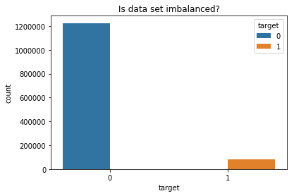

```python
ax=sns.countplot(x='target', hue="target", data=train)
plt.title('Is data set imbalanced?');
```

It is a binary classification problem, and the **data set is unbalanced**. About 6% of the training data are insincere questions (target=1) and rest of them are sincere.

### Visualizations

**Word Cloud:**

Now let us look at the frequently occuring words in the data by creating a word cloud on the 'question_text' column.

```python
from wordcloud import WordCloud, STOPWORDS, ImageColorGenerator

# Thanks : https://www.kaggle.com/aashita/word-clouds-of-various-shapes ##
def plot_wordcloud(text, mask=None, max_words=200, max_font_size=100, figure_size=(24.0,16.0),
                   title = None, title_size=40, image_color=False):
    stopwords = set(STOPWORDS)
    more_stopwords = {'one', 'br', 'Po', 'th', 'sayi', 'fo', 'Unknown'}
    stopwords = stopwords.union(more_stopwords)

    wordcloud = WordCloud(background_color='black',
                    stopwords = stopwords,
                    max_words = max_words,
                    max_font_size = max_font_size,
                    random_state = 42,
                    width=800,
                    height=400,
                    mask = mask)
    wordcloud.generate(str(text))

    plt.figure(figsize=figure_size)
    if image_color:
        image_colors = ImageColorGenerator(mask);
        plt.imshow(wordcloud.recolor(color_func=image_colors), interpolation="bilinear");
        plt.title(title, fontdict={'size': title_size,
                                  'verticalalignment': 'bottom'})
    else:
        plt.imshow(wordcloud);
        plt.title(title, fontdict={'size': title_size, 'color': 'black',
                                  'verticalalignment': 'bottom'})
    plt.axis('off');
    plt.tight_layout()
```

Let's check the most frequent words in each of the classes separately.

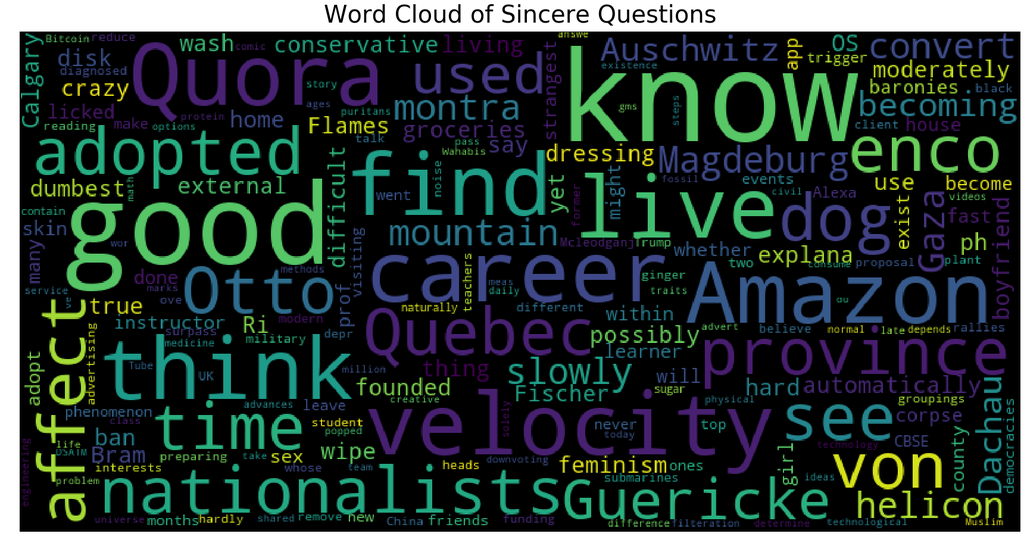

```python
plot_wordcloud(train.loc[train.target == 0,"question_text"],
               title="Word Cloud of Sincere Questions")
```

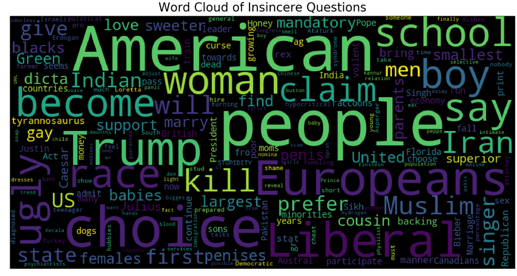

```python
plot_wordcloud(train.loc[train.target == 1,"question_text"],
               title="Word Cloud of Insincere Questions")
```

**Word Frequency plot of sincere & insincere questions:**

```python
from collections import defaultdict
train1_df = train[train["target"]==1]
train0_df = train[train["target"]==0]

## custom function for ngram generation ##
def generate_ngrams(text, n_gram=1):
    token = [token for token in text.lower().split(" ") if token != "" if token not in STOPWORDS]
    ngrams = zip(*[token[i:] for i in range(n_gram)])
    return [" ".join(ngram) for ngram in ngrams]

## Get the single words for sincere questions ##
freq_dict = defaultdict(int)
for sent in train0_df["question_text"]:
    for word in generate_ngrams(sent, n_gram=1):
        freq_dict[word] += 1
fd0_sorted = pd.DataFrame(sorted(freq_dict.items(), key=lambda x: x[1])[::-1])
fd0_sorted.columns = ["word", "wordcount"]

## Get the single words for insincere questions ##
freq_dict = defaultdict(int)
for sent in train1_df["question_text"]:
    for word in generate_ngrams(sent):
        freq_dict[word] += 1
fd1_sorted = pd.DataFrame(sorted(freq_dict.items(), key=lambda x: x[1])[::-1])
fd1_sorted.columns = ["word", "wordcount"]
```

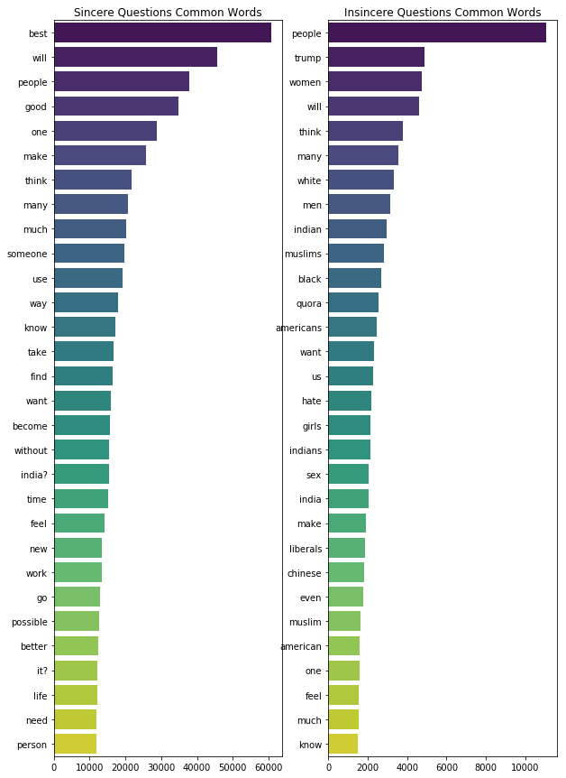

```python
# plot 30 most common words in sincere and insincere questions
fig, axes = plt.subplots(nrows=1, ncols=2, figsize=(10, 15))
p1 = sns.barplot(x='wordcount', y='word', data=fd0_sorted.head(30), palette='viridis', ax = axes[0])
p1.set_title('Sincere Questions Common Words')
p1.set_xlabel('')
p1.set_ylabel('')

p2 = sns.barplot(x='wordcount', y='word', data=fd1_sorted.head(30), palette='viridis', ax = axes[1])
p2.set_title('Insincere Questions Common Words')
p2.set_xlabel('')
p2.set_ylabel('')

fig.savefig('sincere_insincere_words.png')
```

**Observations:**

- Some of the top words are common across both the classes like 'people', 'will', 'think' etc
- The other top words in sincere questions after excluding the common ones at the very top are 'best', 'good' etc
- The other top words in insincere questions after excluding the common ones are 'trump', 'women', 'white' etc

Now lets also create **bigram** frequency plots for both the classes separately to get more idea.

```python
## Get the bigrams for sincere questions ##
freq_dict = defaultdict(int)
for sent in train0_df["question_text"]:
    for word in generate_ngrams(sent, n_gram=2):
        freq_dict[word] += 1
fd0_sorted = pd.DataFrame(sorted(freq_dict.items(), key=lambda x: x[1])[::-1])
fd0_sorted.columns = ["word", "wordcount"]

## Get the bigrams for insincere questions ##
freq_dict = defaultdict(int)
for sent in train1_df["question_text"]:
    for word in generate_ngrams(sent, n_gram=2):
        freq_dict[word] += 1
fd1_sorted = pd.DataFrame(sorted(freq_dict.items(), key=lambda x: x[1])[::-1])
fd1_sorted.columns = ["word", "wordcount"]
```

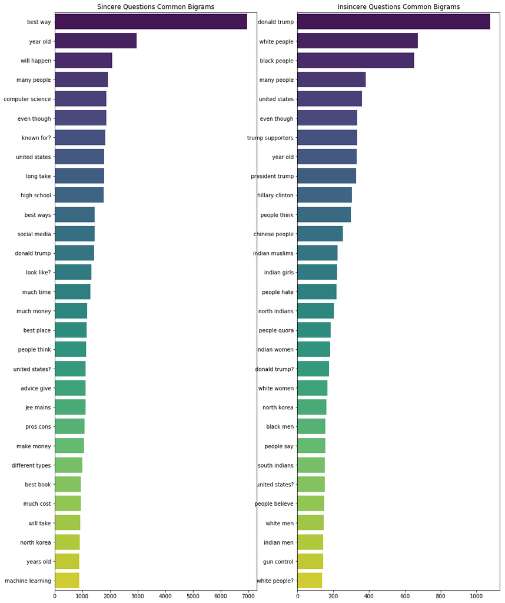

```python
# plot 30 most common words in sincere and insincere questions
fig, axes = plt.subplots(nrows=1, ncols=2, figsize=(15, 20))
p1 = sns.barplot(x='wordcount', y='word', data=fd0_sorted.head(30), palette='viridis', ax = axes[0])
p1.set_title('Sincere Questions Common Bigrams')
p1.set_xlabel('')
p1.set_ylabel('')

p2 = sns.barplot(x='wordcount', y='word', data=fd1_sorted.head(30), palette='viridis', ax = axes[1])
p2.set_title('Insincere Questions Common Bigrams')
p2.set_xlabel('')
p2.set_ylabel('')

fig.savefig('sincere_insincere_bigrams.png')
```

**Observations:**

- Some of the top words are common across both the classes like 'even though', 'year old', 'united states', 'many people'
- The other top words in sincere questions after excluding the common ones at the very top are 'best way', 'computer science', 'will happen' etc
- The other top words in insincere questions after excluding the common ones are 'white people', 'black people', 'chinese people', 'trump supporters'
  - a lot of bigrams related to US presidency, Trump and Hilary
  - a lot of bigrams indicating rasism

Now let us look at the **trigram** plots as well.

```python
## Get the bigrams for sincere questions ##
freq_dict = defaultdict(int)
for sent in train0_df["question_text"]:
    for word in generate_ngrams(sent, n_gram=3):
        freq_dict[word] += 1
fd0_sorted = pd.DataFrame(sorted(freq_dict.items(), key=lambda x: x[1])[::-1])
fd0_sorted.columns = ["word", "wordcount"]

## Get the bigrams for insincere questions ##
freq_dict = defaultdict(int)
for sent in train1_df["question_text"]:
    for word in generate_ngrams(sent, n_gram=3):
        freq_dict[word] += 1
fd1_sorted = pd.DataFrame(sorted(freq_dict.items(), key=lambda x: x[1])[::-1])
fd1_sorted.columns = ["word", "wordcount"]
```

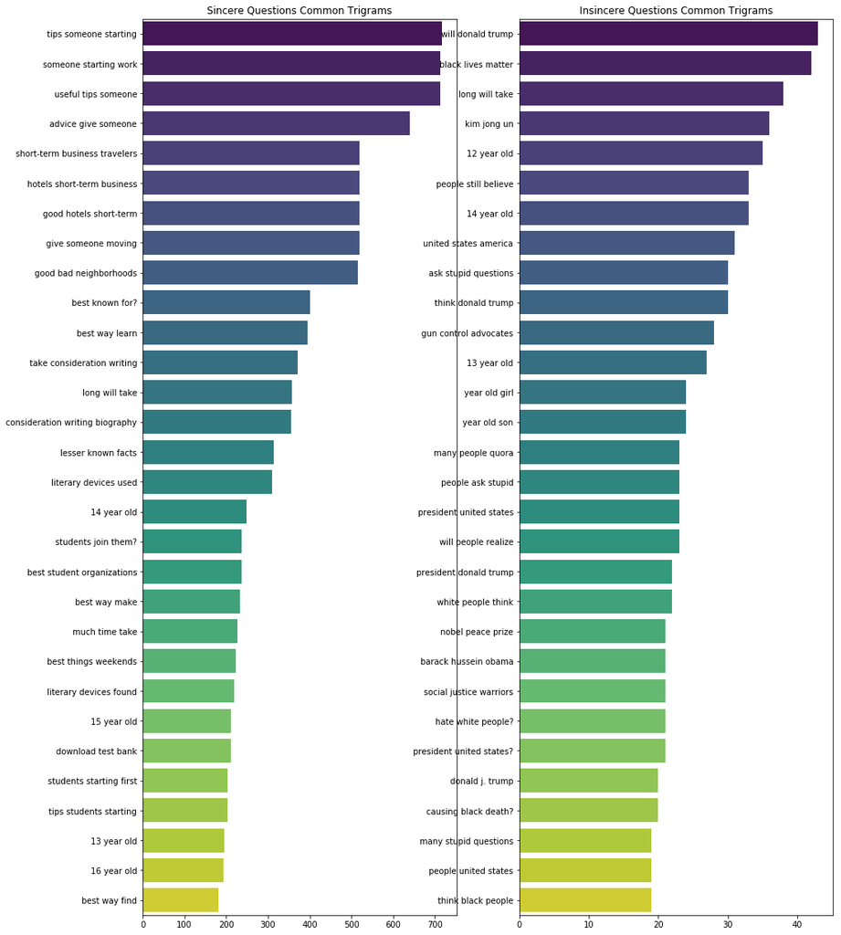

```python
# plot 30 most common words in sincere and insincere questions
fig, axes = plt.subplots(nrows=1, ncols=2, figsize=(15, 20))
p1 = sns.barplot(x='wordcount', y='word', data=fd0_sorted.head(30), palette='viridis', ax = axes[0])
p1.set_title('Sincere Questions Common Trigrams')
p1.set_xlabel('')
p1.set_ylabel('')

p2 = sns.barplot(x='wordcount', y='word', data=fd1_sorted.head(30), palette='viridis', ax = axes[1])
p2.set_title('Insincere Questions Common Trigrams')
p2.set_xlabel('')
p2.set_ylabel('')

fig.savefig('sincere_insincere_trigrams.png')
```

### Meta Features:

Now let us create some meta features and then look at how they are distributed between the classes. The ones that we will create are:

1. Number of words in the text
2. Number of unique words in the text
3. Number of characters in the text
4. Number of stopwords
5. Number of punctuations
6. Number of upper case words
7. Number of title case words
8. Average length of the words

```python
## Number of words in the text ##
train["num_words"] = train["question_text"].apply(lambda x: len(str(x).split()))

## Number of unique words in the text ##
train["num_unique_words"] = train["question_text"].apply(lambda x: len(set(str(x).split())))

## Number of characters in the text ##
train["num_chars"] = train["question_text"].apply(lambda x: len(str(x)))

## Number of stopwords in the text ##
train["num_stopwords"] = train["question_text"].apply(lambda x: len([w for w in str(x).lower().split() if w in STOPWORDS]))

## Number of punctuations in the text ##
train["num_punctuations"] =train['question_text'].apply(lambda x: len([c for c in str(x) if c in string.punctuation]) )

## Number of title case words in the text ##
train["num_words_upper"] = train["question_text"].apply(lambda x: len([w for w in str(x).split() if w.isupper()]))

## Number of title case words in the text ##
train["num_words_title"] = train["question_text"].apply(lambda x: len([w for w in str(x).split() if w.istitle()]))

## Average length of the words in the text ##
train["mean_word_len"] = train["question_text"].apply(lambda x: np.mean([len(w) for w in str(x).split()]))
```

#### Histograms

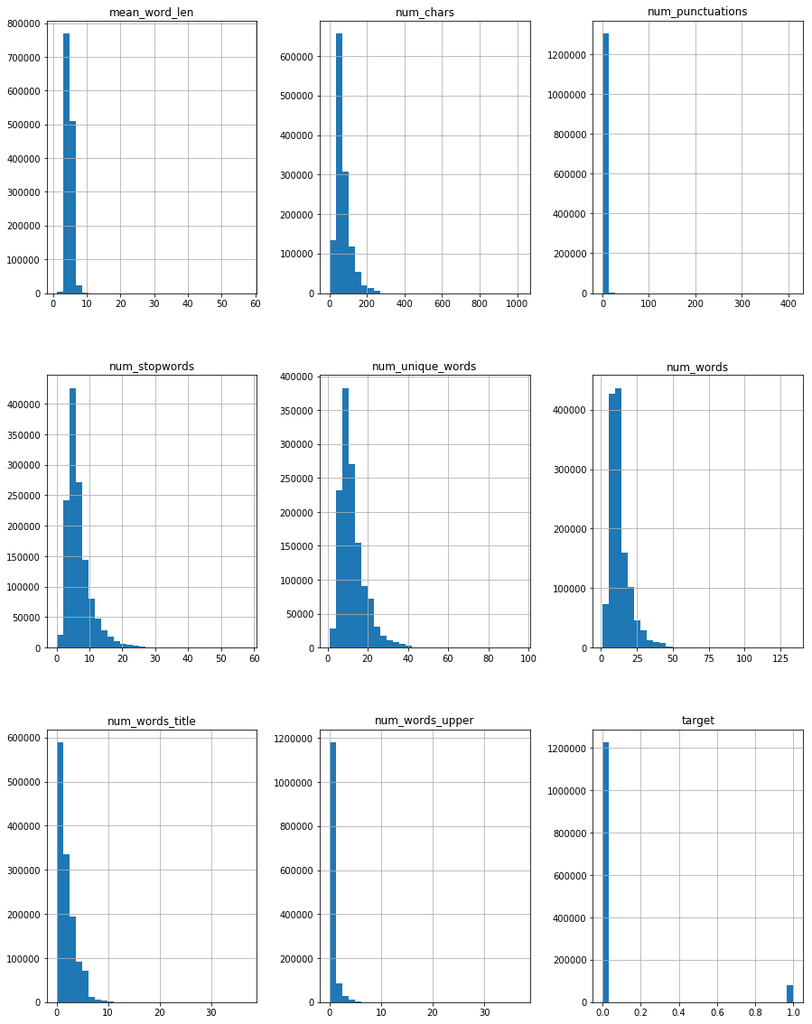

```python
train.hist(figsize=(15,20), bins=30)
plt.figure()
```

Pandas plots are quick to make but we cannot easily see the distributions apart that all are right-skewed.

#### Distribution Plots with seaborn

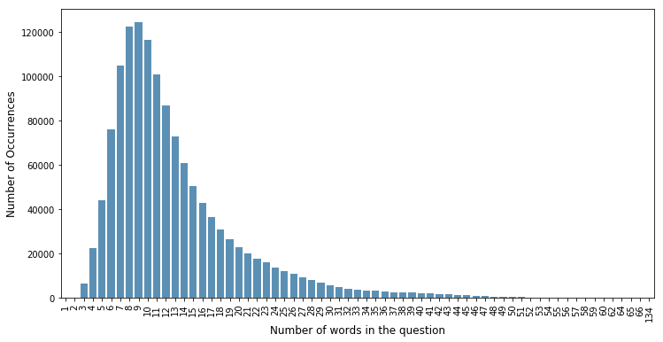

```python
cnt = train['num_words'].value_counts()

plt.figure(figsize=(12,6))
sns.barplot(cnt.index, cnt.values, alpha=0.8, color=color[0])
plt.ylabel('Number of Occurrences', fontsize=12)
plt.xlabel('Number of words in the question', fontsize=12)
#plt.xlim(120,180)
plt.xticks(rotation='vertical')
plt.show()
```

In this plot we can clearly see that most questions have around 10 words, with the long right tail to 50+ words.

```python
train['num_words'].describe()
```

```
count    1.306122e+06
mean     1.280361e+01
std      7.052437e+00
min      1.000000e+00
25%      8.000000e+00
50%      1.100000e+01
75%      1.500000e+01
max      1.340000e+02
Name: num_words, dtype: float64
```

More formaly: The distribution of words is unimodal, right skewed with mean of 12, standard deviation of 7, and range from 1 to 134. There are few questions with 1 or 2 words as well.

Now let us explore the number of characters distribution as well.

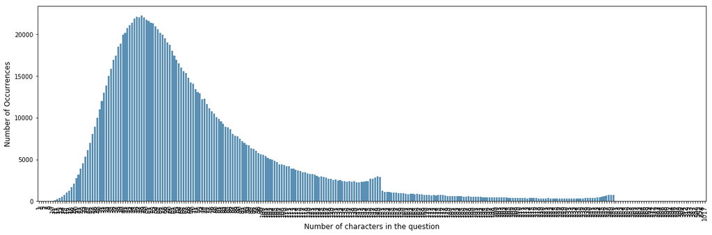

```python
cnt_srs = train['num_chars'].value_counts()

plt.figure(figsize=(20,6))
sns.barplot(cnt_srs.index, cnt_srs.values, alpha=0.8, color=color[0])
plt.ylabel('Number of Occurrences', fontsize=12)
plt.xlabel('Number of characters in the question', fontsize=12)
#plt.xlim(130,160)
plt.xticks(rotation='vertical')
plt.show()
```

Number of characters distribution as well is right skewed. One interesting point is the sudden dip at the 150 character mark. Why is that so?

#### Distribution of meta features vs type of question

Now let us see how these meta features are distributed between both sincere and insincere questions.

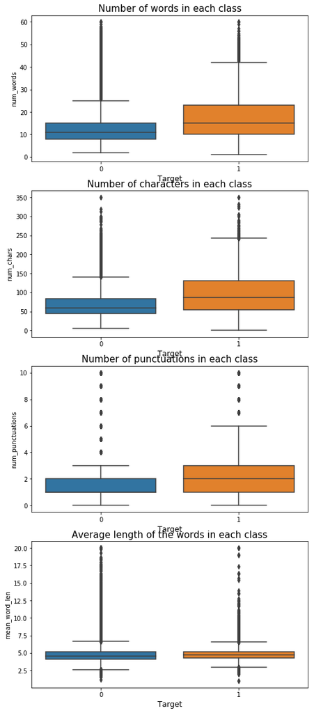

```python
## Truncate some extreme values for better visuals ##
train['num_words'].loc[train['num_words']>60] = 60
train['num_punctuations'].loc[train['num_punctuations']>10] = 10
train['num_chars'].loc[train['num_chars']>350] = 350
train["mean_word_len"].loc[train['mean_word_len']>20] = 20

fig, axes = plt.subplots(4, 1, figsize=(8,20))
sns.boxplot(x='target', y='num_words', data=train, ax=axes[0])
axes[0].set_xlabel('Target', fontsize=12)
axes[0].set_title("Number of words in each class", fontsize=15)

sns.boxplot(x='target', y='num_chars', data=train, ax=axes[1])
axes[1].set_xlabel('Target', fontsize=12)
axes[1].set_title("Number of characters in each class", fontsize=15)

sns.boxplot(x='target', y='num_punctuations', data=train, ax=axes[2])
axes[2].set_xlabel('Target', fontsize=12)
axes[2].set_title("Number of punctuations in each class", fontsize=15)

sns.boxplot(x='target', y='mean_word_len', data=train, ax=axes[3])
axes[3].set_xlabel('Target', fontsize=12)
axes[3].set_title("Average length of the words in each class", fontsize=15)

plt.show()
```

**Inference:** We can see that the insincere questions have:

- higher number of words
- higher number of characters
- more puctuation marks

So this might be a useful feature in our model.

### Next...

After this short explorations to get familiar with dataset, let's proceed with modeling, hyperparameter tuning and ensembling as given in the task.